# DSCI_602_Project_2_Cody_York

Cody York

2022-12-09

## Data Ingestion and Pre-processing

```
The below R code will ingest the data and do any cleanup or preprocessing required. The datasets that will be used for statistics and graphing will also be created here.
```

```r
COVID_19_Deaths <- read_csv("Provisional_COVID-19_Deaths_by_Sex_and_Age.csv")
Covid_19_Total_Deaths <- COVID_19_Deaths[1,10]

Total_Deaths <- COVID_19_Deaths[1,11]

COVID_19_Deaths_by_Age <- COVID_19_Deaths %>%
                            filter(COVID_19_Deaths$State == "United States"
                                   & COVID_19_Deaths$`Age Group` != "All Ages"
                                   & COVID_19_Deaths$Sex == "All Sexes"
                                   & COVID_19_Deaths$Group == "By Total"
                                   ) %>%
                            select(`Age Group`, `COVID-19 Deaths`,
                                   `Total Deaths`)

COVID_19_Deaths_by_Age_DF <- data.frame(COVID_19_Deaths_by_Age)

COVID_19_Deaths_by_Sex <- COVID_19_Deaths %>%
                          filter(COVID_19_Deaths$State == "United States"
                                   & COVID_19_Deaths$`Age Group` == "All Ages"
                                   & COVID_19_Deaths$Sex != "All Sexes"
                                   & COVID_19_Deaths$Group == "By Total"
                                   ) %>%
                            select(Sex, `COVID-19 Deaths`,`Total Deaths`)


COVID_19_Deaths_by_Sex_DF <- data.frame(COVID_19_Deaths_by_Sex)
```

## Graphing if Age Increases Chance of Death by Covid-19

[output not shown]

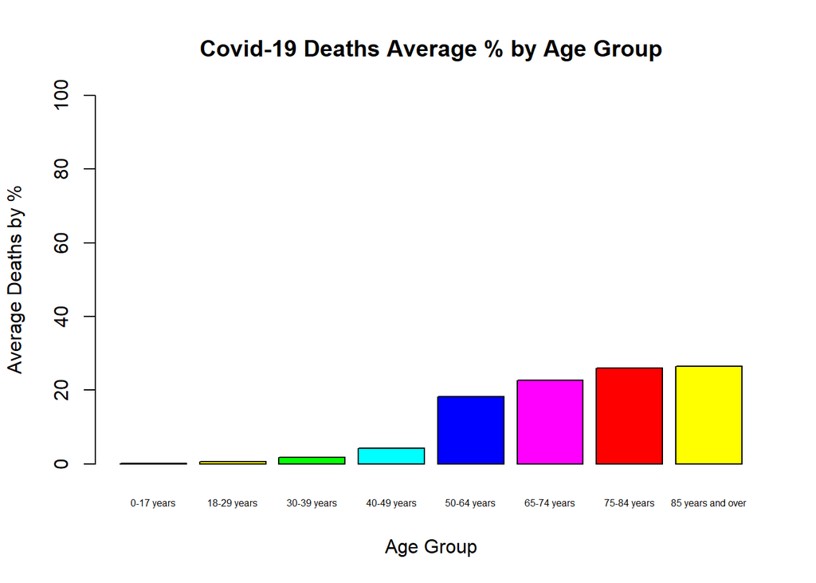

```r
  Covid_19_Avg_Deaths_By_Age <- COVID_19_Deaths_by_Age_DF %>%
                                  group_by(Age.Group) %>%
                                  filter(COVID.19.Deaths != "NA") %>%
                                  summarise(
                                    deaths_by_age = sum(COVID.19.Deaths),
                                    total_deaths_by_age = sum(Total.Deaths),
                                    avg_deaths_by_age = round
                                    (
                                      deaths_by_age / Covid_19_Total_Deaths,
                                      digits = 4
                                    ),
                                    avg_deaths_by_age_from_total = round
                                    (
                                      deaths_by_age / Total_Deaths,
                                      digits = 4
                                    )
                                  )

  age_groups <- c("0-17 years", "18-29 years", "30-39 years", "40-49 years",
                  "50-64 years", "65-74 years", "75-84 years",
                  "85 years and over")

  Covid_19_Avg_Deaths_By_Age_DF <- data.frame(Covid_19_Avg_Deaths_By_Age) %>%
                                   filter(Age.Group %in% age_groups)

  std_dev_of_Covid_19_Avg_Deaths_By_Age <- sd(
    as.numeric(
      unlist(
        Covid_19_Avg_Deaths_By_Age_DF$avg_deaths_by_age
        )
      )
    )

  mean_of_Covid_19_Avg_Deaths_By_Age <- mean(
    as.numeric(
      unlist(
        Covid_19_Avg_Deaths_By_Age_DF$avg_deaths_by_age
        )
      )
    )

 barplot(as.numeric(
   unlist(Covid_19_Avg_Deaths_By_Age_DF$avg_deaths_by_age))*100,
          ylim = c(0,100),
          names.arg = Covid_19_Avg_Deaths_By_Age_DF$Age.Group,
          main = "Covid-19 Deaths Average % by Age Group",
          cex.names = 0.5,
          xlab = "Age Group",
          ylab = "Average Deaths by %",
          border = "black",
          col = rainbow(6)
         )
```

## Graphing Covid-19 Age Deaths Based on Total Deaths

```
The below code will graph the different age groups into a barplot with the calculated average Total Deaths by age. I am multiplying by 100 so we can see a percentage in the graph.
```

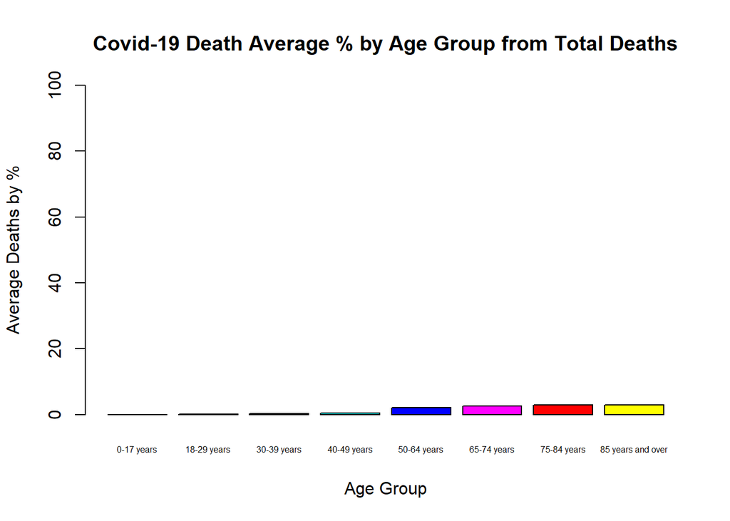

```r
 barplot(as.numeric(
   unlist(Covid_19_Avg_Deaths_By_Age_DF$avg_deaths_by_age_from_total))*100,
          ylim = c(0,100),
          names.arg = Covid_19_Avg_Deaths_By_Age_DF$Age.Group,
          main = "Covid-19 Death Average % by Age Group from Total Deaths",
          cex.names = 0.5,
          xlab = "Age Group",
          ylab = "Average Deaths by %",
          border = "black",
          col = rainbow(6)
         )
```

## Graphing Total Deaths by Age Group

The below code will graph the different age groups into a barplot with the Total Deaths by age. This graph is simply for informational purposes.

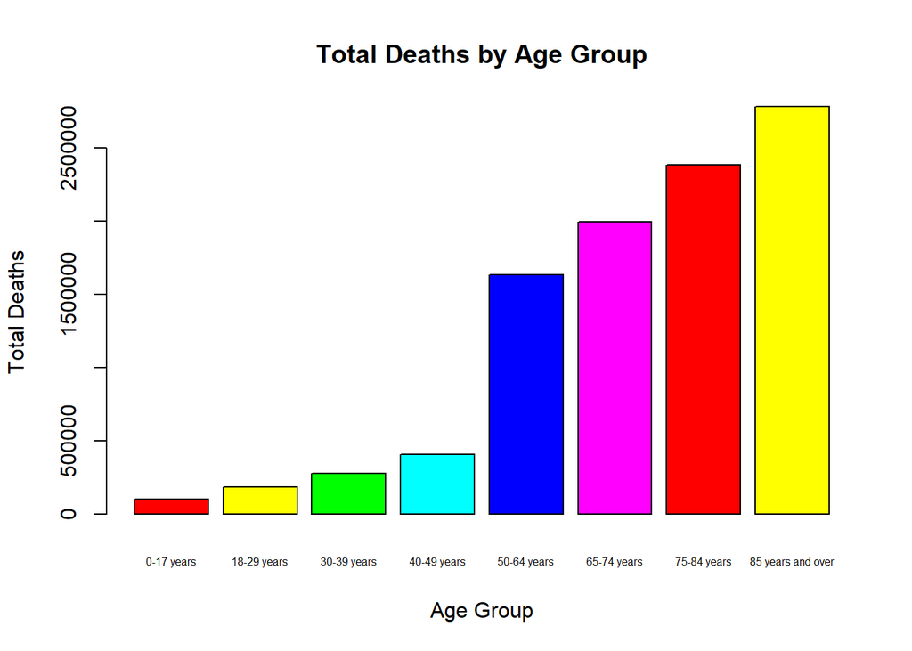

```r
 barplot(as.numeric(
   unlist(Covid_19_Avg_Deaths_By_Age_DF$total_deaths_by_age)),
          names.arg = Covid_19_Avg_Deaths_By_Age_DF$Age.Group,
          main = "Total Deaths by Age Group",
          cex.names = 0.5,
          xlab = "Age Group",
          ylab = "Total Deaths",
          border = "black",
          col = rainbow(6)
         )
```

## Graphing if Gender Increases Chance of Death by Covid-19

The below code will graph the different genders into a barplot with the calculated average Covid-19 Deaths. I am multiplying by 100 so we can see a percentage in the graph. This average was calculated by taking each gender category and dividing it by the earlier created variable Covid_19_Total_Deaths. I have also created the average total deaths by age group using the the earlier created variable Total_Deaths. I have also calculated the mean and standard deviation of the data to be used later.

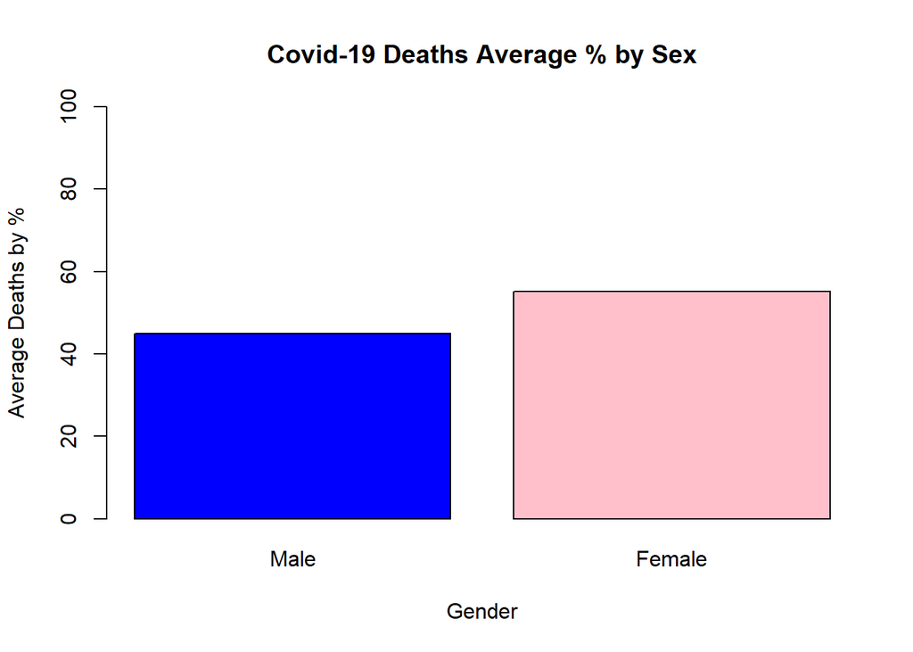

```r
  Covid_19_Avg_Deaths_By_Gender <- COVID_19_Deaths_by_Sex_DF %>%
                                  group_by(Sex) %>%
                                  filter(COVID.19.Deaths != "NA") %>%
                                  summarise(
                                    deaths_by_sex = sum(COVID.19.Deaths),
                                    avg_deaths_by_sex = round
                                    (
                                      deaths_by_sex / Covid_19_Total_Deaths,
                                      digits = 4
                                    ),                                                                             avg_deaths_by_sex_from_total = round
                                    (
                                      deaths_by_sex / Total_Deaths,
                                      digits = 4
                                    ),
                                    total_deaths_by_sex = sum(Total.Deaths)
                                  )

 Covid_19_Avg_Deaths_By_Gender_DF = data.frame(Covid_19_Avg_Deaths_By_Gender)

   std_dev_of_Covid_19_Avg_Deaths_By_Gender <- sd(
    as.numeric(
      unlist(
        Covid_19_Avg_Deaths_By_Gender_DF$avg_deaths_by_sex
        )
      )
    )

  mean_of_Covid_19_Avg_Deaths_By_Gender <- mean(
    as.numeric(
      unlist(
        Covid_19_Avg_Deaths_By_Gender_DF$avg_deaths_by_sex
        )
      )
    )

  barplot(as.numeric(
   unlist(Covid_19_Avg_Deaths_By_Gender_DF$avg_deaths_by_sex))*100,
          ylim = c(0,100),
          names.arg = c("Male", "Female"),
          main = "Covid-19 Deaths Average % by Sex",
          cex.names = 1,
          xlab = "Gender",
          ylab = "Average Deaths by %",
          border = "black",
          col = c("blue", "pink")
         )
```

## Graphing Covid-19 Gender Deaths Based on Total Deaths

The below code will graph the different gender groups into a barplot with the calculated average Total Deaths by gender. I am multiplying by 100 so we can see a percentage in the graph.

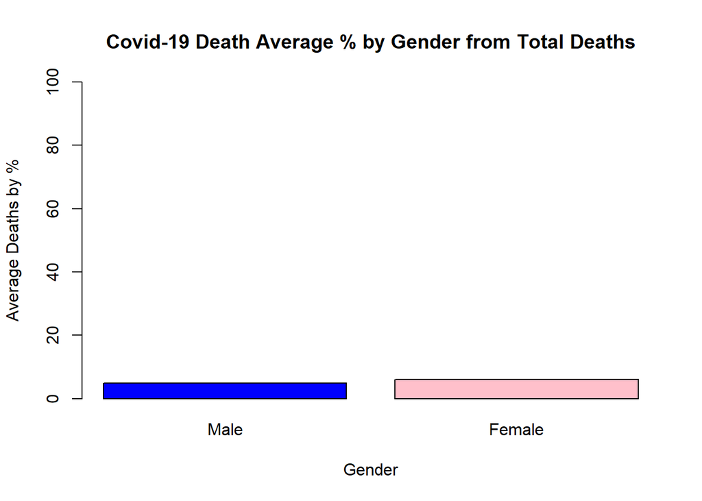

```r
  barplot(as.numeric(
   unlist(Covid_19_Avg_Deaths_By_Gender_DF$avg_deaths_by_sex_from_total))*100,
          ylim = c(0,100),
          names.arg = c("Male", "Female"),
          main = "Covid-19 Death Average % by Gender from Total Deaths",
          cex.names = 1,
          xlab = "Gender",
          ylab = "Average Deaths by %",
          border = "black",
          col = c("blue", "pink")
         )
```

## Graphing Total Deaths by Gender

The below code will graph the different genders into a barplot with the Total Deaths by gender. This graph is simply for informational purposes.

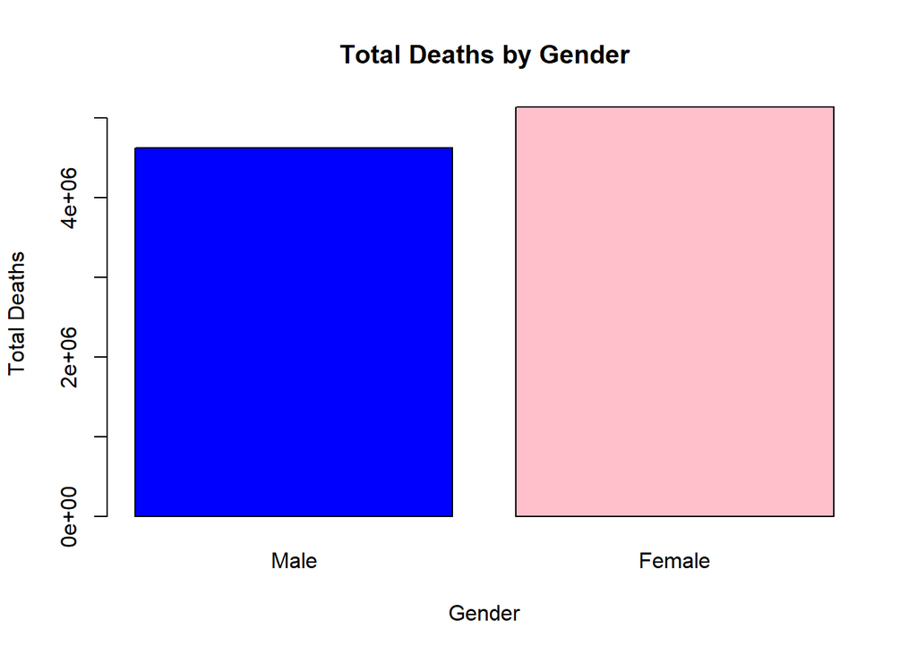

```r
  barplot(as.numeric(
   unlist(Covid_19_Avg_Deaths_By_Gender_DF$total_deaths_by_sex)),
          names.arg = c("Male", "Female"),
          main = "Total Deaths by Gender",
          cex.names = 1,
          xlab = "Gender",
          ylab = "Total Deaths",
          border = "black",
          col = c("blue", "pink")
         )
```

## Hypothesis Testing

[output not shown]

```r
t.test(Covid_19_Avg_Deaths_By_Age_DF$avg_deaths_by_age,
       mu = mean_of_Covid_19_Avg_Deaths_By_Age,
       alternative = "less")
```

```
##
##  One Sample t-test
##
## data:  Covid_19_Avg_Deaths_By_Age_DF$avg_deaths_by_age
## t = 0, df = 7, p-value = 0.5
## alternative hypothesis: true mean is less than 0.1249875
## 95 percent confidence interval:
##      -Inf 0.204645
## sample estimates:
## mean of x
## 0.1249875
```

```r
t.test(Covid_19_Avg_Deaths_By_Gender_DF$avg_deaths_by_sex,
       mu = mean_of_Covid_19_Avg_Deaths_By_Gender,
       alternative = "less")
```

```
##
##  One Sample t-test
##
## data:  Covid_19_Avg_Deaths_By_Gender_DF$avg_deaths_by_sex
## t = 0, df = 1, p-value = 0.5
## alternative hypothesis: true mean is less than 0.5
## 95 percent confidence interval:
##       -Inf 0.8232641
## sample estimates:
## mean of x
##       0.5
```

```r
var.test(as.numeric(unlist(Covid_19_Avg_Deaths_By_Age_DF$avg_deaths_by_age)),
         as.numeric(unlist(Covid_19_Avg_Deaths_By_Gender_DF$avg_deaths_by_sex)))
```

```
##
##  F test to compare two variances
##
## data:  as.numeric(unlist(Covid_19_Avg_Deaths_By_Age_DF$avg_deaths_by_age)) and as.numeric(unlist(Covid_19_Avg_Deaths_By_Gender_DF$avg_deaths_by_sex))
## F = 2.6974, num df = 7, denom df = 1, p-value = 0.8763
## alternative hypothesis: true ratio of variances is not equal to 1
## 95 percent confidence interval:
##   0.002844726 21.775357190
## sample estimates:
## ratio of variances
##           2.697417
```

```r
chisq.test(Covid_19_Avg_Deaths_By_Age_DF$avg_deaths_by_age)
```

```
##
##  Chi-squared test for given probabilities
##
## data:  Covid_19_Avg_Deaths_By_Age_DF$avg_deaths_by_age
## X-squared = 0.79204, df = 7, p-value = 0.9975
```

```r
chisq.test(Covid_19_Avg_Deaths_By_Gender_DF$avg_deaths_by_sex)
```

```
##
##  Chi-squared test for given probabilities
##
## data:  Covid_19_Avg_Deaths_By_Gender_DF$avg_deaths_by_sex
## X-squared = 0.010486, df = 1, p-value = 0.9184
```